# New chronic disease prevalence estimates: summary and comparison with previous values and QOF

2017-04-24

We recently published new estimates of disease prevalence for a range of chronic diseases as part of a wider disease and risk factor prevalence profile which draws together all the estimates from [Fingertips](https://fingertips.phe.org.uk/profile/prevalence).

The new estimates are for:

- Hypertension
- Coronary heart disease
- Stroke
- Heart failure
- COPD
- Depression
- Peripheral arterial disease (PAD)

These estimates were developed by Imperial College and are available for General Practices and lower tier Local Authorities.

The estimates for hypertension, COPD, stroke and coronary heart disease are ‘updates’ of existing values originally created by the Association of Public Health Observatories. The new estimates are not directly comparable with previous values for a number of reasons:

1. Different data sources (see table)
2. Different age bands
3. More model predictors
4. Improved estimation methods

| Disease | Data source (new estimate) | Data source (old estimate) |
| --- | --- | --- |
| Hypertenion | Health Survey for England | Health Survey for England (Mindell et al. 2012) |
| CHD | Whitehall II study (Marmot and Brunner 2005) | Health Survey for England |
| Stroke | Whitehall II study | Health Survey for England |
| PAD | Whitehall II study | NA |
| COPD | CPRD[^1](Herrett et al. 2015) | Health Survey for England |
| Depression | Health Survey for Engand | NA |
| Heart failure | CPRD | NA |

## Methods

We extracted relevant profileIDs and areatype codes using the `profiles` and `area_types` functions. The profileID is 37, and the relevant domainIDs are 1938132820 and 1938133099. The area type IDs are 7 for GPs and 101 for lower tier local authorities respectively.

Using this information we can download the data from Fingertips using the `fingertips_data` function (the downloads may take a few minutes). The first few records are shown below.

| IndicatorID | IndicatorName | ParentCode | ParentName | AreaCode | AreaName | AreaType | Sex | Age | CategoryType | Category | Timeperiod | Value | LowerCIlimit | UpperCIlimit | Count | Denominator | Valuenote | RecentTrend | ComparedtoEnglandvalueorpercentiles | Comparedtosubnationalparentvalueorpercentiles |
| --- | --- | --- | --- | --- | --- | --- | --- | --- | --- | --- | --- | --- | --- | --- | --- | --- | --- | --- | --- | --- |
| 92659 | Estimated prevalence of hypertension (18+) |  |  | E92000001 | England | Country | Persons | 18+ yrs |  |  | 2015 | 20.77941 | NA | NA | NA | NA |  | Cannot be calculated | Not compared | Not compared |
| 92659 | Estimated prevalence of hypertension (18+) | E12000001 | North East region | E06000001 | Hartlepool | District & UA | Persons | 18+ yrs |  |  | 2015 | 23.33363 | 21.44856 | 25.33096 | NA | NA |  | Cannot be calculated | Not compared | Not compared |
| 92659 | Estimated prevalence of hypertension (18+) | E12000001 | North East region | E06000002 | Middlesbrough | District & UA | Persons | 18+ yrs |  |  | 2015 | 19.93244 | 17.96331 | 22.05939 | NA | NA |  | Cannot be calculated | Not compared | Not compared |
| 92659 | Estimated prevalence of hypertension (18+) | E12000001 | North East region | E06000003 | Redcar and Cleveland | District & UA | Persons | 18+ yrs |  |  | 2015 | 24.20986 | 22.38044 | 26.13846 | NA | NA |  | Cannot be calculated | Not compared | Not compared |
| 92659 | Estimated prevalence of hypertension (18+) | E12000001 | North East region | E06000004 | Stockton-on-Tees | District & UA | Persons | 18+ yrs |  |  | 2015 | 20.09999 | 18.15705 | 22.19445 | NA | NA |  | Cannot be calculated | Not compared | Not compared |
| 92659 | Estimated prevalence of hypertension (18+) | E12000001 | North East region | E06000005 | Darlington | District & UA | Persons | 18+ yrs |  |  | 2015 | 21.18244 | 19.07864 | 23.45100 | NA | NA |  | Cannot be calculated | Not compared | Not compared |

The downloaded dataset needs further preparation:

- selecting relevant indicators
- recoding data and extracting disease categories
- categorising estimate types into “New”, “QOF” and “Retired”

# Analysis

## Overall summary

Summary statistics (note there are no local authority values for Isles of Scilly or City of London, due the small numbers and instablity of modelled estimates) are show in the table.

| AreaType | Disease | Estimate type | Count | Min | 10th centile | 25th centile | Median | Mean | 75th centile | 90th cemtile | Max | SD | Missing (%) |
| --- | --- | --- | --- | --- | --- | --- | --- | --- | --- | --- | --- | --- | --- |
| District & UA | CHD | New | 324 | 6.66 | 7.15 | 7.43 | 7.88 | 7.92 | 8.26 | 8.7 | 10.5 | 0.65 | 0.00 |
| District & UA | COPD | New | 324 | 1.49 | 2.18 | 2.53 | 2.99 | 3.01 | 3.47 | 3.9 | 4.9 | 0.66 | 0.00 |
| District & UA | Depresssion | New | 324 | 8.54 | 12.96 | 14.07 | 15.05 | 15.03 | 16.21 | 17.2 | 19.2 | 1.72 | 0.00 |
| District & UA | Heart failure | New | 324 | 0.58 | 1.11 | 1.37 | 1.52 | 1.53 | 1.71 | 1.9 | 4.6 | 0.36 | 0.00 |
| District & UA | Hypertension | New | 324 | 12.79 | 17.11 | 19.12 | 21.07 | 20.79 | 22.80 | 23.8 | 28.2 | 2.72 | 0.00 |
| District & UA | PAD | New | 324 | 0.95 | 1.03 | 1.08 | 1.15 | 1.15 | 1.21 | 1.3 | 1.7 | 0.10 | 0.00 |
| District & UA | Stroke | New | 324 | 3.04 | 3.43 | 3.56 | 3.71 | 3.72 | 3.87 | 4.0 | 4.3 | 0.23 | 0.00 |
| District & UA | Undiagnosed hypertension | New | 324 | 9.16 | 10.89 | 11.61 | 12.22 | 12.15 | 12.75 | 13.3 | 14.4 | 0.93 | 0.00 |
| GP | CHD | New | 7528 | 3.81 | 6.61 | 6.94 | 7.29 | 7.37 | 7.71 | 8.3 | 12.2 | 0.70 | 0.73 |
| GP | CHD | QOF | 7586 | 0.00 | 1.72 | 2.47 | 3.23 | 3.22 | 3.98 | 4.6 | 20.6 | 1.16 | 0.00 |
| GP | CHD | Retired | 7499 | 0.03 | 2.99 | 3.78 | 4.65 | 4.65 | 5.49 | 6.3 | 12.9 | 1.35 | 0.00 |
| GP | COPD | New | 7528 | 0.13 | 1.43 | 1.88 | 2.41 | 2.42 | 2.94 | 3.4 | 13.6 | 0.78 | 0.50 |
| GP | COPD | QOF | 7586 | 0.00 | 0.82 | 1.25 | 1.80 | 1.91 | 2.45 | 3.1 | 10.8 | 0.93 | 0.00 |
| GP | COPD | Retired | 7499 | 0.62 | 2.02 | 2.39 | 2.91 | 3.00 | 3.56 | 4.1 | 6.5 | 0.81 | 0.00 |
| GP | Depresssion | New | 7528 | 5.16 | 10.86 | 13.70 | 15.78 | 15.34 | 17.35 | 18.8 | 23.5 | 2.95 | 0.00 |
| GP | Depresssion | QOF | 7586 | 0.00 | 3.98 | 5.72 | 7.79 | 8.16 | 10.12 | 12.7 | 34.1 | 3.55 | 0.00 |
| GP | Heart failure | New | 7520 | 0.09 | 0.77 | 1.07 | 1.38 | 1.36 | 1.64 | 1.9 | 11.9 | 0.46 | 0.00 |
| GP | Heart failure | QOF | 7586 | 0.00 | 0.35 | 0.51 | 0.71 | 0.76 | 0.94 | 1.2 | 7.6 | 0.37 | 0.00 |
| GP | Hypertension | New | 7528 | 2.00 | 16.47 | 19.00 | 21.24 | 20.86 | 23.11 | 24.7 | 49.3 | 3.55 | 0.00 |
| GP | Hypertension | QOF | 7586 | 0.00 | 9.27 | 11.88 | 14.22 | 14.01 | 16.33 | 18.3 | 54.8 | 3.74 | 0.00 |
| GP | Hypertension | Retired | 7502 | 4.22 | 18.91 | 22.07 | 24.95 | 24.60 | 27.42 | 29.6 | 44.7 | 4.42 | 0.00 |
| GP | PAD | New | 7528 | 0.58 | 0.87 | 0.94 | 1.00 | 1.00 | 1.06 | 1.1 | 1.8 | 0.09 | 0.64 |
| GP | Stroke | New | 7528 | 2.10 | 3.27 | 3.51 | 3.72 | 3.70 | 3.91 | 4.1 | 6.2 | 0.32 | 0.73 |
| GP | Stroke | QOF | 7586 | 0.00 | 0.83 | 1.23 | 1.71 | 1.71 | 2.14 | 2.5 | 22.6 | 0.73 | 0.00 |
| GP | Stroke | Retired | 7503 | 0.16 | 1.31 | 1.67 | 2.04 | 2.03 | 2.39 | 2.7 | 5.4 | 0.57 | 0.00 |
| GP | Undiagnosed hypertension | New | 7528 | 3.76 | 10.46 | 11.33 | 12.12 | 12.00 | 12.77 | 13.4 | 20.1 | 1.24 | 0.00 |

## Regional summaries

|  | Disease | ParentName | Count | Min | 10th centile | 25th centile | Median | Mean | 75th centile | 90th cemtile | Max | SD | Missing (%) |
| --- | --- | --- | --- | --- | --- | --- | --- | --- | --- | --- | --- | --- | --- |
| 1 | CHD | East Midlands region | 40 | 6.65764726 | 7.3302143223 | 7.51780957225 | 7.8206506715 | 7.9911809162 | 8.18043966775 | 9.1351243754 | 10.52582229 | 0.763819577402565 | 0 |
| 2 | CHD | East of England region | 47 | 6.918922602 | 7.0904650844 | 7.409530345 | 7.921841459 | 7.87895351114894 | 8.2298064185 | 8.6606835374 | 9.277584419 | 0.603248595202369 | 0 |
| 3 | CHD | London region | 32 | 7.088439602 | 7.290485983 | 7.623431831 | 8.2772491255 | 8.29117436975 | 8.7347603215 | 9.3242694338 | 10.48230683 | 0.822177063931484 | 0 |
| 4 | CHD | North East region | 12 | 7.461176435 | 7.6377795361 | 7.866738094 | 8.0383467585 | 8.02806168225 | 8.20841731525 | 8.4360400963 | 8.602510949 | 0.329443905653953 | 0 |
| 5 | CHD | North West region | 39 | 6.840080667 | 7.403134625 | 7.782995379 | 8.104537045 | 8.10647755223077 | 8.3457395415 | 8.8575810084 | 9.398944145 | 0.59832350793861 | 0 |
| 6 | CHD | South East region | 67 | 6.686023789 | 6.986997883 | 7.195259799 | 7.530021261 | 7.59256756377612 | 8.0019577665 | 8.2024058526 | 8.729772502 | 0.4933444500793 | 0 |
| 7 | CHD | South West region | 36 | 6.851595175 | 7.144004989 | 7.38526388175 | 7.779890589 | 7.740959002 | 8.07392569375 | 8.217714464 | 8.839719312 | 0.471564931580066 | 0 |
| 8 | CHD | West Midlands region | 30 | 6.980041045 | 7.2658107124 | 7.6640062 | 7.937313971 | 8.1093002455 | 8.44143284 | 9.0719019383 | 10.02471406 | 0.764014010643045 | 0 |
| 9 | CHD | Yorkshire and the Humber region | 21 | 7.103913721 | 7.301042092 | 7.515770096 | 8.026752221 | 8.000240731 | 8.352312278 | 8.706705416 | 8.923095853 | 0.54380134092076 | 0 |
| 10 | COPD | East Midlands region | 40 | 2.238899075 | 2.4915142298 | 2.690673784 | 3.0731273995 | 3.063170736525 | 3.311209351 | 3.703053484 | 4.862650793 | 0.520621634981417 | 0 |

[output cut: 62 more lines]

## Summary variation plot

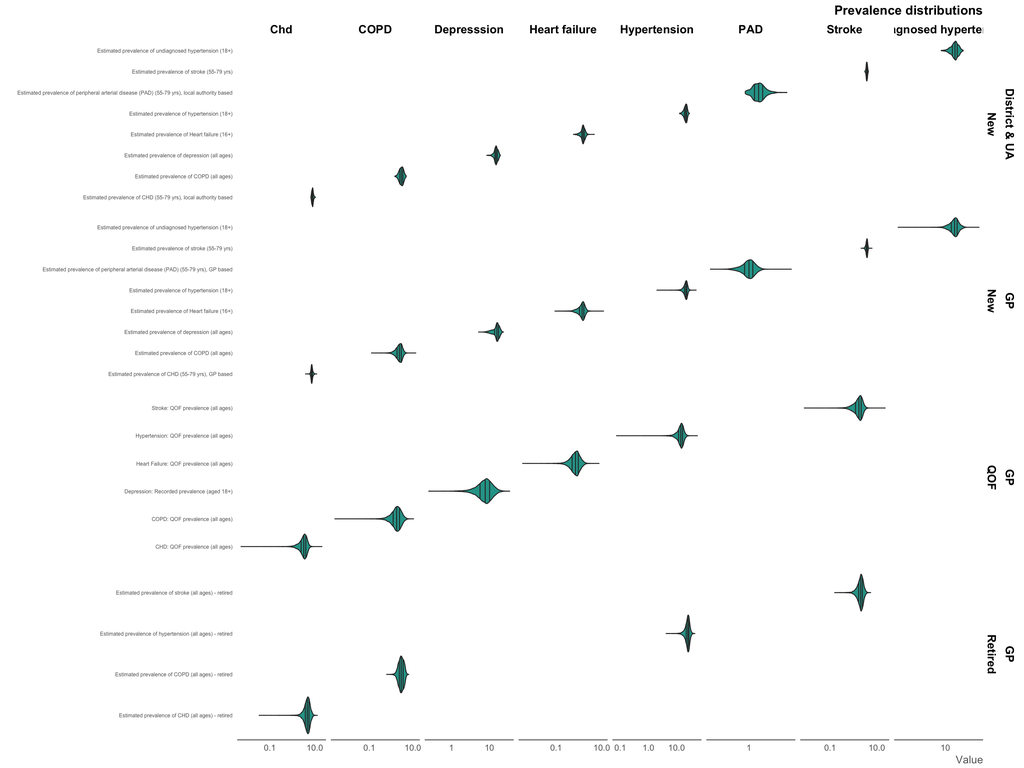

Using the `ggmap` package. (Kahle and Wickham 2013)

## Cluster analysis

Group together local authorities and general practices on the basis similarity across prevalence estimates. Using k-means analysis.

[output not shown]

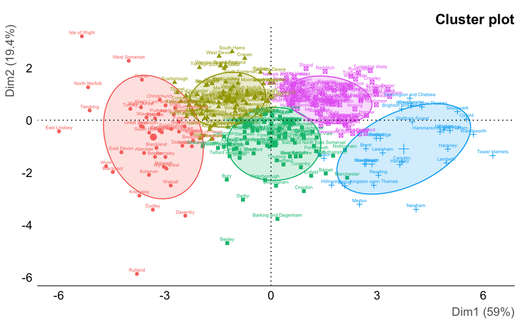

### Dimensions

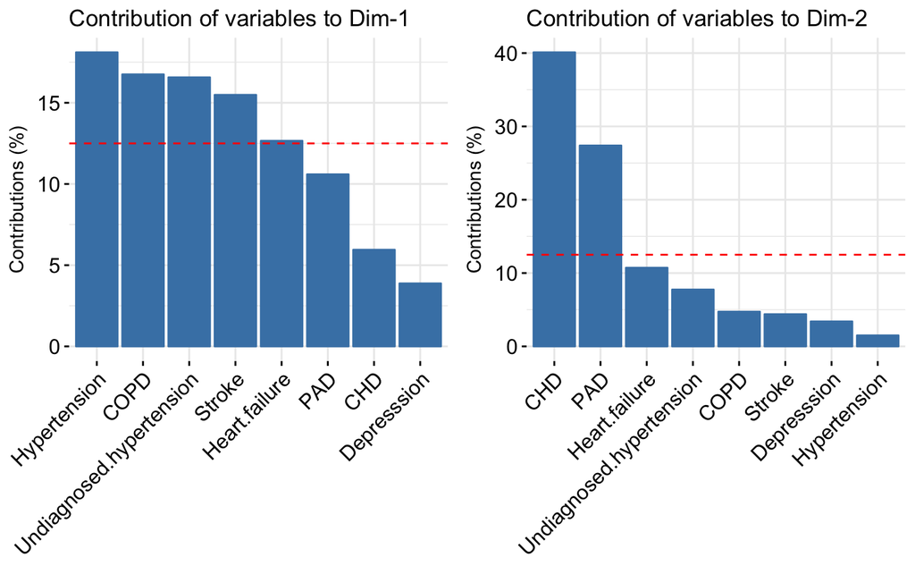

### References

Herrett, Emily, Arlene M. Gallagher, Krishnan Bhaskaran, Harriet Forbes, Rohini Mathur, Tjeerd van Staa, and Liam Smeeth. 2015. “Data Resource Profile: Clinical Practice Research Datalink (CPRD).” *International Journal of Epidemiology* 44 (3): 827–36. doi:10.1093/ije/dyv098.

Kahle, David, and Hadley Wickham. 2013. “ggmap: Spatial Visualization with ggplot2.” *The R Journal* 5 (1): 144–61. doi:10.1023/A:1009843930701.

Marmot, Michael, and Eric Brunner. 2005. “Cohort profile: The Whitehall II study.” *International Journal of Epidemiology* 34 (2): 251–56. doi:10.1093/ije/dyh372.

Mindell, Jennifer, Jane P. Biddulph, Vasant Hirani, Emanuel Stamatakis, Rachel Craig, Susan Nunn, and Nicola Shelton. 2012. “Cohort profile: The health survey for england.” *International Journal of Epidemiology* 41 (6): 1585–93. doi:10.1093/ije/dyr199.

[^1]: Clinical Practice Research Datalink - a GP dataset